# Optimal Treatment Analysis

## Outcome Variable

**Outcome Variable:** ever_stunted

## Predictor Variables

**Intervention Variable:** pers_wast

**Adjustment Set:**

- arm
- sex
- W_mage
- meducyrs
- month
- brthmon
- W_parity
- delta_W_mage
- delta_meducyrs
- delta_month
- delta_brthmon
- delta_W_parity

## Stratifying Variables

The analysis was stratified on these variable(s):

- agecat
- studyid
- country

## Data Summary

| agecat | studyid | country | pers_wast | ever_stunted | n_cell | n |
| --- | --- | --- | --- | --- | --- | --- |
| 0-24 months (no birth st.) | ki0047075b-MAL-ED | BANGLADESH | 0 | 0 | 98 | 217 |
| 0-24 months (no birth st.) | ki0047075b-MAL-ED | BANGLADESH | 0 | 1 | 112 | 217 |
| 0-24 months (no birth st.) | ki0047075b-MAL-ED | BANGLADESH | 1 | 0 | 6 | 217 |
| 0-24 months (no birth st.) | ki0047075b-MAL-ED | BANGLADESH | 1 | 1 | 1 | 217 |
| 0-24 months (no birth st.) | ki0047075b-MAL-ED | BRAZIL | 0 | 0 | 178 | 208 |
| 0-24 months (no birth st.) | ki0047075b-MAL-ED | BRAZIL | 0 | 1 | 29 | 208 |
| 0-24 months (no birth st.) | ki0047075b-MAL-ED | BRAZIL | 1 | 0 | 1 | 208 |
| 0-24 months (no birth st.) | ki0047075b-MAL-ED | BRAZIL | 1 | 1 | 0 | 208 |
| 0-24 months (no birth st.) | ki0047075b-MAL-ED | INDIA | 0 | 0 | 89 | 209 |
| 0-24 months (no birth st.) | ki0047075b-MAL-ED | INDIA | 0 | 1 | 101 | 209 |
| 0-24 months (no birth st.) | ki0047075b-MAL-ED | INDIA | 1 | 0 | 12 | 209 |
| 0-24 months (no birth st.) | ki0047075b-MAL-ED | INDIA | 1 | 1 | 7 | 209 |
| 0-24 months (no birth st.) | ki0047075b-MAL-ED | NEPAL | 0 | 0 | 153 | 212 |
| 0-24 months (no birth st.) | ki0047075b-MAL-ED | NEPAL | 0 | 1 | 54 | 212 |
| 0-24 months (no birth st.) | ki0047075b-MAL-ED | NEPAL | 1 | 0 | 4 | 212 |
| 0-24 months (no birth st.) | ki0047075b-MAL-ED | NEPAL | 1 | 1 | 1 | 212 |
| 0-24 months (no birth st.) | ki0047075b-MAL-ED | PERU | 0 | 0 | 115 | 266 |
| 0-24 months (no birth st.) | ki0047075b-MAL-ED | PERU | 0 | 1 | 151 | 266 |
| 0-24 months (no birth st.) | ki0047075b-MAL-ED | PERU | 1 | 0 | 0 | 266 |
| 0-24 months (no birth st.) | ki0047075b-MAL-ED | PERU | 1 | 1 | 0 | 266 |
| 0-24 months (no birth st.) | ki0047075b-MAL-ED | SOUTH AFRICA | 0 | 0 | 136 | 280 |
| 0-24 months (no birth st.) | ki0047075b-MAL-ED | SOUTH AFRICA | 0 | 1 | 137 | 280 |
| 0-24 months (no birth st.) | ki0047075b-MAL-ED | SOUTH AFRICA | 1 | 0 | 7 | 280 |
| 0-24 months (no birth st.) | ki0047075b-MAL-ED | SOUTH AFRICA | 1 | 1 | 0 | 280 |
| 0-24 months (no birth st.) | ki0047075b-MAL-ED | TANZANIA, UNITED REPUBLIC OF | 0 | 0 | 41 | 219 |
| 0-24 months (no birth st.) | ki0047075b-MAL-ED | TANZANIA, UNITED REPUBLIC OF | 0 | 1 | 178 | 219 |
| 0-24 months (no birth st.) | ki0047075b-MAL-ED | TANZANIA, UNITED REPUBLIC OF | 1 | 0 | 0 | 219 |
| 0-24 months (no birth st.) | ki0047075b-MAL-ED | TANZANIA, UNITED REPUBLIC OF | 1 | 1 | 0 | 219 |
| 0-24 months (no birth st.) | ki1000108-CMC-V-BCS-2002 | INDIA | 0 | 0 | 24 | 293 |
| 0-24 months (no birth st.) | ki1000108-CMC-V-BCS-2002 | INDIA | 0 | 1 | 228 | 293 |

[output cut: 198 more lines]

The following strata were considered:

- agecat: 0-24 months (no birth st.), studyid: ki0047075b-MAL-ED, country: BANGLADESH
- agecat: 0-24 months (no birth st.), studyid: ki0047075b-MAL-ED, country: BRAZIL
- agecat: 0-24 months (no birth st.), studyid: ki0047075b-MAL-ED, country: INDIA
- agecat: 0-24 months (no birth st.), studyid: ki0047075b-MAL-ED, country: NEPAL
- agecat: 0-24 months (no birth st.), studyid: ki0047075b-MAL-ED, country: PERU
- agecat: 0-24 months (no birth st.), studyid: ki0047075b-MAL-ED, country: SOUTH AFRICA
- agecat: 0-24 months (no birth st.), studyid: ki0047075b-MAL-ED, country: TANZANIA, UNITED REPUBLIC OF
- agecat: 0-24 months (no birth st.), studyid: ki1000108-CMC-V-BCS-2002, country: INDIA
- agecat: 0-24 months (no birth st.), studyid: ki1000108-IRC, country: INDIA
- agecat: 0-24 months (no birth st.), studyid: ki1000109-EE, country: PAKISTAN
- agecat: 0-24 months (no birth st.), studyid: ki1000109-ResPak, country: PAKISTAN
- agecat: 0-24 months (no birth st.), studyid: ki1017093b-PROVIDE, country: BANGLADESH
- agecat: 0-24 months (no birth st.), studyid: ki1066203-TanzaniaChild2, country: TANZANIA, UNITED REPUBLIC OF
- agecat: 0-24 months (no birth st.), studyid: ki1101329-Keneba, country: GAMBIA
- agecat: 0-24 months (no birth st.), studyid: ki1112895-Guatemala BSC, country: GUATEMALA
- agecat: 0-24 months (no birth st.), studyid: ki1113344-GMS-Nepal, country: NEPAL
- agecat: 0-24 months (no birth st.), studyid: ki1114097-CMIN, country: BANGLADESH
- agecat: 0-24 months (no birth st.), studyid: ki1114097-CMIN, country: PERU
- agecat: 0-24 months (no birth st.), studyid: ki1114097-CONTENT, country: PERU
- agecat: 0-6 months (no birth st.), studyid: ki0047075b-MAL-ED, country: BANGLADESH
- agecat: 0-6 months (no birth st.), studyid: ki0047075b-MAL-ED, country: BRAZIL
- agecat: 0-6 months (no birth st.), studyid: ki0047075b-MAL-ED, country: INDIA
- agecat: 0-6 months (no birth st.), studyid: ki0047075b-MAL-ED, country: NEPAL
- agecat: 0-6 months (no birth st.), studyid: ki0047075b-MAL-ED, country: PERU
- agecat: 0-6 months (no birth st.), studyid: ki0047075b-MAL-ED, country: SOUTH AFRICA
- agecat: 0-6 months (no birth st.), studyid: ki0047075b-MAL-ED, country: TANZANIA, UNITED REPUBLIC OF
- agecat: 0-6 months (no birth st.), studyid: ki1000108-CMC-V-BCS-2002, country: INDIA
- agecat: 0-6 months (no birth st.), studyid: ki1000108-IRC, country: INDIA
- agecat: 0-6 months (no birth st.), studyid: ki1000109-EE, country: PAKISTAN
- agecat: 0-6 months (no birth st.), studyid: ki1000109-ResPak, country: PAKISTAN
- agecat: 0-6 months (no birth st.), studyid: ki1017093b-PROVIDE, country: BANGLADESH
- agecat: 0-6 months (no birth st.), studyid: ki1066203-TanzaniaChild2, country: TANZANIA, UNITED REPUBLIC OF
- agecat: 0-6 months (no birth st.), studyid: ki1101329-Keneba, country: GAMBIA
- agecat: 0-6 months (no birth st.), studyid: ki1112895-Guatemala BSC, country: GUATEMALA
- agecat: 0-6 months (no birth st.), studyid: ki1113344-GMS-Nepal, country: NEPAL
- agecat: 0-6 months (no birth st.), studyid: ki1114097-CMIN, country: BANGLADESH
- agecat: 0-6 months (no birth st.), studyid: ki1114097-CMIN, country: PERU
- agecat: 0-6 months (no birth st.), studyid: ki1114097-CONTENT, country: PERU
- agecat: 6-24 months, studyid: ki0047075b-MAL-ED, country: BANGLADESH
- agecat: 6-24 months, studyid: ki0047075b-MAL-ED, country: BRAZIL
- agecat: 6-24 months, studyid: ki0047075b-MAL-ED, country: INDIA
- agecat: 6-24 months, studyid: ki0047075b-MAL-ED, country: NEPAL
- agecat: 6-24 months, studyid: ki0047075b-MAL-ED, country: PERU
- agecat: 6-24 months, studyid: ki0047075b-MAL-ED, country: SOUTH AFRICA
- agecat: 6-24 months, studyid: ki0047075b-MAL-ED, country: TANZANIA, UNITED REPUBLIC OF
- agecat: 6-24 months, studyid: ki1000108-CMC-V-BCS-2002, country: INDIA
- agecat: 6-24 months, studyid: ki1000108-IRC, country: INDIA
- agecat: 6-24 months, studyid: ki1000109-EE, country: PAKISTAN
- agecat: 6-24 months, studyid: ki1000109-ResPak, country: PAKISTAN
- agecat: 6-24 months, studyid: ki1017093b-PROVIDE, country: BANGLADESH
- agecat: 6-24 months, studyid: ki1066203-TanzaniaChild2, country: TANZANIA, UNITED REPUBLIC OF
- agecat: 6-24 months, studyid: ki1101329-Keneba, country: GAMBIA
- agecat: 6-24 months, studyid: ki1112895-Guatemala BSC, country: GUATEMALA
- agecat: 6-24 months, studyid: ki1113344-GMS-Nepal, country: NEPAL
- agecat: 6-24 months, studyid: ki1114097-CMIN, country: BANGLADESH
- agecat: 6-24 months, studyid: ki1114097-CMIN, country: PERU
- agecat: 6-24 months, studyid: ki1114097-CONTENT, country: PERU

### Dropped Strata

Some strata were dropped due to rare outcomes:

- agecat: 0-24 months (no birth st.), studyid: ki0047075b-MAL-ED, country: BANGLADESH
- agecat: 0-24 months (no birth st.), studyid: ki0047075b-MAL-ED, country: BRAZIL
- agecat: 0-24 months (no birth st.), studyid: ki0047075b-MAL-ED, country: NEPAL
- agecat: 0-24 months (no birth st.), studyid: ki0047075b-MAL-ED, country: PERU
- agecat: 0-24 months (no birth st.), studyid: ki0047075b-MAL-ED, country: SOUTH AFRICA
- agecat: 0-24 months (no birth st.), studyid: ki0047075b-MAL-ED, country: TANZANIA, UNITED REPUBLIC OF
- agecat: 0-24 months (no birth st.), studyid: ki1000108-CMC-V-BCS-2002, country: INDIA
- agecat: 0-24 months (no birth st.), studyid: ki1000109-EE, country: PAKISTAN
- agecat: 0-24 months (no birth st.), studyid: ki1112895-Guatemala BSC, country: GUATEMALA
- agecat: 0-24 months (no birth st.), studyid: ki1114097-CMIN, country: BANGLADESH
- agecat: 0-24 months (no birth st.), studyid: ki1114097-CONTENT, country: PERU
- agecat: 0-6 months (no birth st.), studyid: ki0047075b-MAL-ED, country: BANGLADESH
- agecat: 0-6 months (no birth st.), studyid: ki0047075b-MAL-ED, country: BRAZIL
- agecat: 0-6 months (no birth st.), studyid: ki0047075b-MAL-ED, country: NEPAL
- agecat: 0-6 months (no birth st.), studyid: ki0047075b-MAL-ED, country: PERU
- agecat: 0-6 months (no birth st.), studyid: ki0047075b-MAL-ED, country: SOUTH AFRICA
- agecat: 0-6 months (no birth st.), studyid: ki0047075b-MAL-ED, country: TANZANIA, UNITED REPUBLIC OF
- agecat: 0-6 months (no birth st.), studyid: ki1112895-Guatemala BSC, country: GUATEMALA
- agecat: 0-6 months (no birth st.), studyid: ki1114097-CMIN, country: BANGLADESH
- agecat: 0-6 months (no birth st.), studyid: ki1114097-CONTENT, country: PERU
- agecat: 6-24 months, studyid: ki0047075b-MAL-ED, country: BANGLADESH
- agecat: 6-24 months, studyid: ki0047075b-MAL-ED, country: BRAZIL
- agecat: 6-24 months, studyid: ki0047075b-MAL-ED, country: INDIA
- agecat: 6-24 months, studyid: ki0047075b-MAL-ED, country: NEPAL
- agecat: 6-24 months, studyid: ki0047075b-MAL-ED, country: PERU
- agecat: 6-24 months, studyid: ki0047075b-MAL-ED, country: SOUTH AFRICA
- agecat: 6-24 months, studyid: ki0047075b-MAL-ED, country: TANZANIA, UNITED REPUBLIC OF
- agecat: 6-24 months, studyid: ki1000108-CMC-V-BCS-2002, country: INDIA
- agecat: 6-24 months, studyid: ki1000109-EE, country: PAKISTAN
- agecat: 6-24 months, studyid: ki1000109-ResPak, country: PAKISTAN
- agecat: 6-24 months, studyid: ki1017093b-PROVIDE, country: BANGLADESH
- agecat: 6-24 months, studyid: ki1112895-Guatemala BSC, country: GUATEMALA
- agecat: 6-24 months, studyid: ki1114097-CMIN, country: BANGLADESH
- agecat: 6-24 months, studyid: ki1114097-CMIN, country: PERU
- agecat: 6-24 months, studyid: ki1114097-CONTENT, country: PERU

## Methods Detail

We’re interested in the causal parameters $E[Y_a]$ for all values of $a \in \mathcal{A}$. These parameters represent the mean outcome if, possibly contrary to fact, we intervened to set all units to have $A=a$. Under the randomization and positivity assumptions, these are identified by the statistical parameters $\psi_a=E_W[E_{Y|A,W}(Y|A=a,W)]$. In addition, we’re interested in the mean of $Y$, $E[Y]$ under no intervention (the observed mean). We will estimate these parameters by using SuperLearner to fit the relevant likelihood factors – $E_{Y|A,W}(Y|A=a,W)$ and $p(A=a|W)$, and then updating our likelihood fit using a joint TMLE.

For unadjusted analyses ($W=\{\}$), initial likelihoods were estimated using Lrnr_glm to estimate the simple $E(Y|A)$ and Lrnr_mean to estimate $p(A)$. For adjusted analyses, a small library containing Lrnr_glmnet, Lrnr_xgboost, and Lrnr_mean was used.

Having estimated these parameters, we will then use the delta method to estimate relative risks and attributable risks relative to a prespecified baseline level of $A$.

# Results Detail

## Results Plots

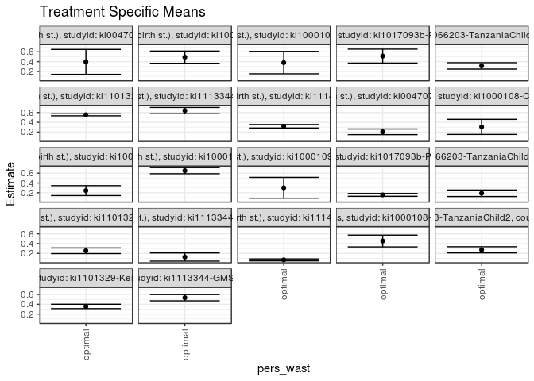

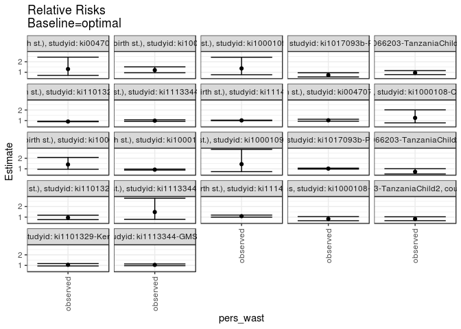

## Results Table

### Parameter: TSM

| agecat | studyid | country | intervention_level | baseline_level | estimate | ci_lower | ci_upper |
| --- | --- | --- | --- | --- | --- | --- | --- |
| 0-24 months (no birth st.) | ki0047075b-MAL-ED | INDIA | optimal | NA | 0.3950115 | 0.1405425 | 0.6494805 |
| 0-24 months (no birth st.) | ki1000108-IRC | INDIA | optimal | NA | 0.4909057 | 0.3668520 | 0.6149595 |
| 0-24 months (no birth st.) | ki1000109-ResPak | PAKISTAN | optimal | NA | 0.3803466 | 0.1517467 | 0.6089466 |
| 0-24 months (no birth st.) | ki1017093b-PROVIDE | BANGLADESH | optimal | NA | 0.5131231 | 0.3712529 | 0.6549933 |
| 0-24 months (no birth st.) | ki1066203-TanzaniaChild2 | TANZANIA, UNITED REPUBLIC OF | optimal | NA | 0.3132517 | 0.2482182 | 0.3782852 |
| 0-24 months (no birth st.) | ki1101329-Keneba | GAMBIA | optimal | NA | 0.5536617 | 0.5327485 | 0.5745748 |
| 0-24 months (no birth st.) | ki1113344-GMS-Nepal | NEPAL | optimal | NA | 0.6391215 | 0.5760119 | 0.7022312 |
| 0-24 months (no birth st.) | ki1114097-CMIN | PERU | optimal | NA | 0.3183204 | 0.2821763 | 0.3544645 |
| 0-6 months (no birth st.) | ki0047075b-MAL-ED | INDIA | optimal | NA | 0.2051636 | 0.1475470 | 0.2627802 |
| 0-6 months (no birth st.) | ki1000108-CMC-V-BCS-2002 | INDIA | optimal | NA | 0.3062216 | 0.1518652 | 0.4605779 |
| 0-6 months (no birth st.) | ki1000108-IRC | INDIA | optimal | NA | 0.2439203 | 0.1417043 | 0.3461364 |
| 0-6 months (no birth st.) | ki1000109-EE | PAKISTAN | optimal | NA | 0.6505439 | 0.5884513 | 0.7126364 |
| 0-6 months (no birth st.) | ki1000109-ResPak | PAKISTAN | optimal | NA | 0.3014465 | 0.0887336 | 0.5141593 |
| 0-6 months (no birth st.) | ki1017093b-PROVIDE | BANGLADESH | optimal | NA | 0.1558644 | 0.1270298 | 0.1846990 |
| 0-6 months (no birth st.) | ki1066203-TanzaniaChild2 | TANZANIA, UNITED REPUBLIC OF | optimal | NA | 0.1892754 | 0.1225882 | 0.2559626 |
| 0-6 months (no birth st.) | ki1101329-Keneba | GAMBIA | optimal | NA | 0.2539963 | 0.1964361 | 0.3115565 |
| 0-6 months (no birth st.) | ki1113344-GMS-Nepal | NEPAL | optimal | NA | 0.1262575 | 0.0426919 | 0.2098230 |
| 0-6 months (no birth st.) | ki1114097-CMIN | PERU | optimal | NA | 0.0683098 | 0.0487339 | 0.0878856 |
| 6-24 months | ki1000108-IRC | INDIA | optimal | NA | 0.4531515 | 0.3324827 | 0.5738204 |
| 6-24 months | ki1066203-TanzaniaChild2 | TANZANIA, UNITED REPUBLIC OF | optimal | NA | 0.2733704 | 0.2107475 | 0.3359932 |
| 6-24 months | ki1101329-Keneba | GAMBIA | optimal | NA | 0.3562248 | 0.3112529 | 0.4011967 |
| 6-24 months | ki1113344-GMS-Nepal | NEPAL | optimal | NA | 0.5342467 | 0.4701483 | 0.5983451 |

### Parameter: E(Y)

| agecat | studyid | country | intervention_level | baseline_level | estimate | ci_lower | ci_upper |
| --- | --- | --- | --- | --- | --- | --- | --- |
| 0-24 months (no birth st.) | ki0047075b-MAL-ED | INDIA | observed | NA | 0.5167464 | 0.4488350 | 0.5846578 |
| 0-24 months (no birth st.) | ki1000108-IRC | INDIA | observed | NA | 0.5916667 | 0.5408218 | 0.6425115 |
| 0-24 months (no birth st.) | ki1000109-ResPak | PAKISTAN | observed | NA | 0.5198020 | 0.4507336 | 0.5888704 |
| 0-24 months (no birth st.) | ki1017093b-PROVIDE | BANGLADESH | observed | NA | 0.3753943 | 0.3376725 | 0.4131162 |
| 0-24 months (no birth st.) | ki1066203-TanzaniaChild2 | TANZANIA, UNITED REPUBLIC OF | observed | NA | 0.2988814 | 0.2798990 | 0.3178639 |
| 0-24 months (no birth st.) | ki1101329-Keneba | GAMBIA | observed | NA | 0.5044763 | 0.4837388 | 0.5252138 |
| 0-24 months (no birth st.) | ki1113344-GMS-Nepal | NEPAL | observed | NA | 0.6336449 | 0.5927799 | 0.6745099 |
| 0-24 months (no birth st.) | ki1114097-CMIN | PERU | observed | NA | 0.3237082 | 0.2879308 | 0.3594857 |
| 0-6 months (no birth st.) | ki0047075b-MAL-ED | INDIA | observed | NA | 0.2105263 | 0.1551227 | 0.2659300 |
| 0-6 months (no birth st.) | ki1000108-CMC-V-BCS-2002 | INDIA | observed | NA | 0.3835616 | 0.3276935 | 0.4394298 |
| 0-6 months (no birth st.) | ki1000108-IRC | INDIA | observed | NA | 0.3444444 | 0.2952897 | 0.3935992 |
| 0-6 months (no birth st.) | ki1000109-EE | PAKISTAN | observed | NA | 0.6024096 | 0.5415000 | 0.6633193 |
| 0-6 months (no birth st.) | ki1000109-ResPak | PAKISTAN | observed | NA | 0.4356436 | 0.3670959 | 0.5041912 |
| 0-6 months (no birth st.) | ki1017093b-PROVIDE | BANGLADESH | observed | NA | 0.1593060 | 0.1307970 | 0.1878149 |
| 0-6 months (no birth st.) | ki1066203-TanzaniaChild2 | TANZANIA, UNITED REPUBLIC OF | observed | NA | 0.1369128 | 0.1226581 | 0.1511674 |
| 0-6 months (no birth st.) | ki1101329-Keneba | GAMBIA | observed | NA | 0.2412713 | 0.2235253 | 0.2590172 |
| 0-6 months (no birth st.) | ki1113344-GMS-Nepal | NEPAL | observed | NA | 0.1869159 | 0.1538509 | 0.2199809 |
| 0-6 months (no birth st.) | ki1114097-CMIN | PERU | observed | NA | 0.0744681 | 0.0543935 | 0.0945427 |
| 6-24 months | ki1000108-IRC | INDIA | observed | NA | 0.3771186 | 0.3151523 | 0.4390850 |
| 6-24 months | ki1066203-TanzaniaChild2 | TANZANIA, UNITED REPUBLIC OF | observed | NA | 0.2259675 | 0.2054816 | 0.2464534 |
| 6-24 months | ki1101329-Keneba | GAMBIA | observed | NA | 0.3752393 | 0.3512585 | 0.3992201 |
| 6-24 months | ki1113344-GMS-Nepal | NEPAL | observed | NA | 0.5610329 | 0.5138522 | 0.6082135 |

### Parameter: RR

| agecat | studyid | country | intervention_level | baseline_level | estimate | ci_lower | ci_upper |
| --- | --- | --- | --- | --- | --- | --- | --- |
| 0-24 months (no birth st.) | ki0047075b-MAL-ED | INDIA | observed | optimal | 1.3081807 | 0.7041480 | 2.4303652 |
| 0-24 months (no birth st.) | ki1000108-IRC | INDIA | observed | optimal | 1.2052551 | 0.9583916 | 1.5157061 |
| 0-24 months (no birth st.) | ki1000109-ResPak | PAKISTAN | observed | optimal | 1.3666534 | 0.7700016 | 2.4256332 |
| 0-24 months (no birth st.) | ki1017093b-PROVIDE | BANGLADESH | observed | optimal | 0.7315872 | 0.5587527 | 0.9578833 |
| 0-24 months (no birth st.) | ki1066203-TanzaniaChild2 | TANZANIA, UNITED REPUBLIC OF | observed | optimal | 0.9541255 | 0.7817716 | 1.1644776 |
| 0-24 months (no birth st.) | ki1101329-Keneba | GAMBIA | observed | optimal | 0.9111635 | 0.8941381 | 0.9285130 |
| 0-24 months (no birth st.) | ki1113344-GMS-Nepal | NEPAL | observed | optimal | 0.9914309 | 0.9179684 | 1.0707725 |
| 0-24 months (no birth st.) | ki1114097-CMIN | PERU | observed | optimal | 1.0169258 | 0.9970716 | 1.0371754 |
| 0-6 months (no birth st.) | ki0047075b-MAL-ED | INDIA | observed | optimal | 1.0261386 | 0.9348310 | 1.1263646 |
| 0-6 months (no birth st.) | ki1000108-CMC-V-BCS-2002 | INDIA | observed | optimal | 1.2525625 | 0.7794465 | 2.0128551 |
| 0-6 months (no birth st.) | ki1000108-IRC | INDIA | observed | optimal | 1.4121187 | 0.9576544 | 2.0822536 |
| 0-6 months (no birth st.) | ki1000109-EE | PAKISTAN | observed | optimal | 0.9260093 | 0.8802118 | 0.9741895 |
| 0-6 months (no birth st.) | ki1000109-ResPak | PAKISTAN | observed | optimal | 1.4451773 | 0.7346964 | 2.8427215 |
| 0-6 months (no birth st.) | ki1017093b-PROVIDE | BANGLADESH | observed | optimal | 1.0220809 | 0.9784388 | 1.0676697 |
| 0-6 months (no birth st.) | ki1066203-TanzaniaChild2 | TANZANIA, UNITED REPUBLIC OF | observed | optimal | 0.7233520 | 0.5145229 | 1.0169386 |
| 0-6 months (no birth st.) | ki1101329-Keneba | GAMBIA | observed | optimal | 0.9499008 | 0.7645096 | 1.1802487 |
| 0-6 months (no birth st.) | ki1113344-GMS-Nepal | NEPAL | observed | optimal | 1.4804343 | 0.7860003 | 2.7884032 |
| 0-6 months (no birth st.) | ki1114097-CMIN | PERU | observed | optimal | 1.0901527 | 0.9973593 | 1.1915796 |
| 6-24 months | ki1000108-IRC | INDIA | observed | optimal | 0.8322131 | 0.6575330 | 1.0532986 |
| 6-24 months | ki1066203-TanzaniaChild2 | TANZANIA, UNITED REPUBLIC OF | observed | optimal | 0.8265985 | 0.6632038 | 1.0302490 |
| 6-24 months | ki1101329-Keneba | GAMBIA | observed | optimal | 1.0533779 | 0.9443454 | 1.1749991 |
| 6-24 months | ki1113344-GMS-Nepal | NEPAL | observed | optimal | 1.0501382 | 0.9711447 | 1.1355571 |

### Parameter: PAR

| agecat | studyid | country | intervention_level | baseline_level | estimate | ci_lower | ci_upper |
| --- | --- | --- | --- | --- | --- | --- | --- |
| 0-24 months (no birth st.) | ki0047075b-MAL-ED | INDIA | optimal | NA | 0.1217349 | -0.1220758 | 0.3655457 |
| 0-24 months (no birth st.) | ki1000108-IRC | INDIA | optimal | NA | 0.1007609 | -0.0112143 | 0.2127361 |
| 0-24 months (no birth st.) | ki1000109-ResPak | PAKISTAN | optimal | NA | 0.1394554 | -0.0777922 | 0.3567030 |
| 0-24 months (no birth st.) | ki1017093b-PROVIDE | BANGLADESH | optimal | NA | -0.1377288 | -0.2751028 | -0.0003548 |
| 0-24 months (no birth st.) | ki1066203-TanzaniaChild2 | TANZANIA, UNITED REPUBLIC OF | optimal | NA | -0.0143703 | -0.0767643 | 0.0480238 |
| 0-24 months (no birth st.) | ki1101329-Keneba | GAMBIA | optimal | NA | -0.0491854 | -0.0589985 | -0.0393723 |
| 0-24 months (no birth st.) | ki1113344-GMS-Nepal | NEPAL | optimal | NA | -0.0054767 | -0.0546696 | 0.0437163 |
| 0-24 months (no birth st.) | ki1114097-CMIN | PERU | optimal | NA | 0.0053878 | -0.0008773 | 0.0116530 |
| 0-6 months (no birth st.) | ki0047075b-MAL-ED | INDIA | optimal | NA | 0.0053627 | -0.0137825 | 0.0245078 |
| 0-6 months (no birth st.) | ki1000108-CMC-V-BCS-2002 | INDIA | optimal | NA | 0.0773401 | -0.0677169 | 0.2223970 |
| 0-6 months (no birth st.) | ki1000108-IRC | INDIA | optimal | NA | 0.1005241 | 0.0052824 | 0.1957659 |
| 0-6 months (no birth st.) | ki1000109-EE | PAKISTAN | optimal | NA | -0.0481342 | -0.0797103 | -0.0165581 |
| 0-6 months (no birth st.) | ki1000109-ResPak | PAKISTAN | optimal | NA | 0.1341971 | -0.0692980 | 0.3376923 |
| 0-6 months (no birth st.) | ki1017093b-PROVIDE | BANGLADESH | optimal | NA | 0.0034416 | -0.0033762 | 0.0102595 |
| 0-6 months (no birth st.) | ki1066203-TanzaniaChild2 | TANZANIA, UNITED REPUBLIC OF | optimal | NA | -0.0523627 | -0.1168595 | 0.0121342 |
| 0-6 months (no birth st.) | ki1101329-Keneba | GAMBIA | optimal | NA | -0.0127250 | -0.0678463 | 0.0423963 |
| 0-6 months (no birth st.) | ki1113344-GMS-Nepal | NEPAL | optimal | NA | 0.0606584 | -0.0197150 | 0.1410319 |
| 0-6 months (no birth st.) | ki1114097-CMIN | PERU | optimal | NA | 0.0061583 | -0.0000897 | 0.0124063 |
| 6-24 months | ki1000108-IRC | INDIA | optimal | NA | -0.0760329 | -0.1816464 | 0.0295806 |
| 6-24 months | ki1066203-TanzaniaChild2 | TANZANIA, UNITED REPUBLIC OF | optimal | NA | -0.0474028 | -0.1073046 | 0.0124989 |
| 6-24 months | ki1101329-Keneba | GAMBIA | optimal | NA | 0.0190145 | -0.0199349 | 0.0579639 |
| 6-24 months | ki1113344-GMS-Nepal | NEPAL | optimal | NA | 0.0267862 | -0.0148465 | 0.0684188 |

### Parameter: PAF

| agecat | studyid | country | intervention_level | baseline_level | estimate | ci_lower | ci_upper |
| --- | --- | --- | --- | --- | --- | --- | --- |
| 0-24 months (no birth st.) | ki0047075b-MAL-ED | INDIA | optimal | NA | 0.2355796 | -0.4201560 | 0.5885392 |
| 0-24 months (no birth st.) | ki1000108-IRC | INDIA | optimal | NA | 0.1703002 | -0.0434149 | 0.3402415 |
| 0-24 months (no birth st.) | ki1000109-ResPak | PAKISTAN | optimal | NA | 0.2682856 | -0.2986986 | 0.5877365 |
| 0-24 months (no birth st.) | ki1017093b-PROVIDE | BANGLADESH | optimal | NA | -0.3668910 | -0.7897006 | -0.0439685 |
| 0-24 months (no birth st.) | ki1066203-TanzaniaChild2 | TANZANIA, UNITED REPUBLIC OF | optimal | NA | -0.0480802 | -0.2791460 | 0.1412458 |
| 0-24 months (no birth st.) | ki1101329-Keneba | GAMBIA | optimal | NA | -0.0974979 | -0.1183954 | -0.0769909 |
| 0-24 months (no birth st.) | ki1113344-GMS-Nepal | NEPAL | optimal | NA | -0.0086432 | -0.0893622 | 0.0660948 |
| 0-24 months (no birth st.) | ki1114097-CMIN | PERU | optimal | NA | 0.0166441 | -0.0029370 | 0.0358430 |
| 0-6 months (no birth st.) | ki0047075b-MAL-ED | INDIA | optimal | NA | 0.0254728 | -0.0697121 | 0.1121880 |
| 0-6 months (no birth st.) | ki1000108-CMC-V-BCS-2002 | INDIA | optimal | NA | 0.2016366 | -0.2829617 | 0.5031932 |
| 0-6 months (no birth st.) | ki1000108-IRC | INDIA | optimal | NA | 0.2918442 | -0.0442180 | 0.5197511 |
| 0-6 months (no birth st.) | ki1000109-EE | PAKISTAN | optimal | NA | -0.0799028 | -0.1360902 | -0.0264943 |
| 0-6 months (no birth st.) | ki1000109-ResPak | PAKISTAN | optimal | NA | 0.3080434 | -0.3611064 | 0.6482244 |
| 0-6 months (no birth st.) | ki1017093b-PROVIDE | BANGLADESH | optimal | NA | 0.0216039 | -0.0220364 | 0.0633807 |
| 0-6 months (no birth st.) | ki1066203-TanzaniaChild2 | TANZANIA, UNITED REPUBLIC OF | optimal | NA | -0.3824528 | -0.9435482 | 0.0166564 |
| 0-6 months (no birth st.) | ki1101329-Keneba | GAMBIA | optimal | NA | -0.0527415 | -0.3080280 | 0.1527210 |
| 0-6 months (no birth st.) | ki1113344-GMS-Nepal | NEPAL | optimal | NA | 0.3245226 | -0.2722641 | 0.6413718 |
| 0-6 months (no birth st.) | ki1114097-CMIN | PERU | optimal | NA | 0.0826973 | -0.0026477 | 0.1607778 |
| 6-24 months | ki1000108-IRC | INDIA | optimal | NA | -0.2016153 | -0.5208362 | 0.0506016 |
| 6-24 months | ki1066203-TanzaniaChild2 | TANZANIA, UNITED REPUBLIC OF | optimal | NA | -0.2097772 | -0.5078322 | 0.0293608 |
| 6-24 months | ki1101329-Keneba | GAMBIA | optimal | NA | 0.0506731 | -0.0589346 | 0.1489355 |
| 6-24 months | ki1113344-GMS-Nepal | NEPAL | optimal | NA | 0.0477444 | -0.0297127 | 0.1193750 |